# TP8: Discrete spatial modelling

Author

Lionel Hertzog

Published

August 24, 2026

## 1 Objective

This practical aims at discovering the way to fit, check and interpret models with discrete spatial data. We will see implicit and explicit model structures to fit such data.

In the course we saw the Besag-York-Mollié model for explicitely accounting for the neighborhood structure of the discrete spatial units:

$$y_i \sim N(\mu_i, \sigma_{res})$$

$$\mu_i = \beta_0 + \gamma_{s_i} + ...$$

$$\gamma_{s_i} = \sigma_{spat} (\sqrt{1-\rho} \nu_{s_i} + \sqrt{p}u_{s_i})$$

$\nu_{s_i}$: spatially unstructured random white noise

$u_{s_i}$: structured spatial signal: $u_{s_i} | u_{s_j, s_j \neq s_i, s_j \sim s_i} \sim N(\frac{\sum_{s_j=1}^{n} u_{s_j}}{n}, 1)$

$\rho$: share of spatial variation due to the spatial structure, closer to 1 stronger importance of spatially structured effect

$\sigma_{spat}$: amount of variation between the spatial units

For this practical we will use a dataset of plot-level biomass from the French NFI collected within different (86) sylvoécoregions:

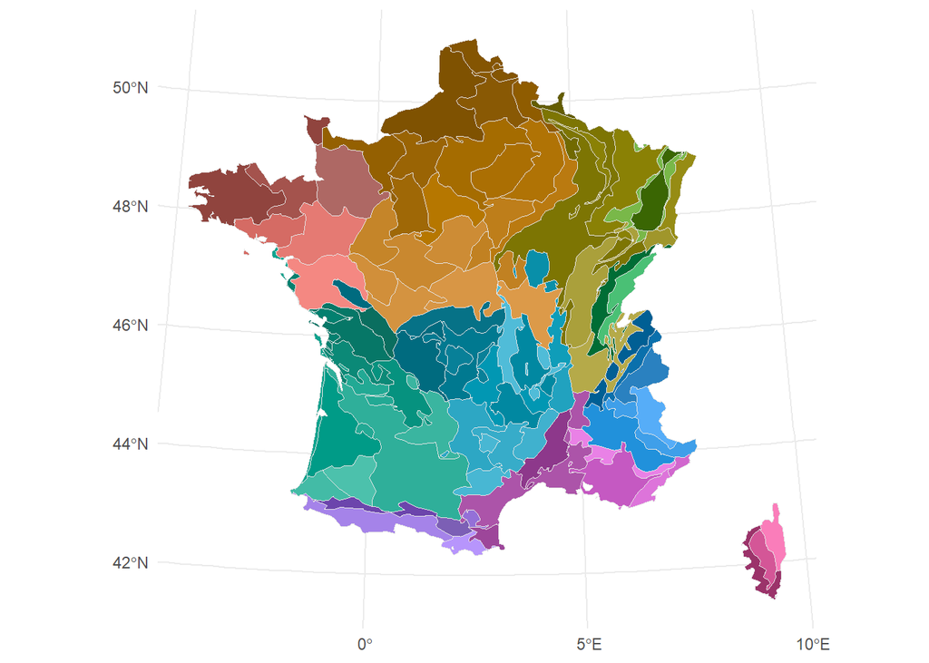

## 2 Read the data

Load the `dat_tp8.csv` into R. Perform quick exploration of the dataset.

```r
here::i_am("practicals/tp8.qmd")
dat <- read.csv("../data/dat_tp8.csv")

# we drop the Corsica regions
dat <- filter(dat, !ser_86 %in% c("K11", "K12", "K13"))

head(dat)
```

```
      idp          pro_psg ser_86      biom
1 1021459 privé - sans psg    C51 139.95228
2 1013705 privé - sans psg    C51 336.26667
3 1013229 privé - sans psg    C51  78.88010
4 1030210 privé - sans psg    C51 304.49445
5 1003663 privé - sans psg    C51  97.59344
6 1007420 privé - sans psg    C52  43.59421
```

We will also need the shapefile of the sylvoécoregions:

```r
library(sf)

ser_shp <- st_read("../data/ser_shp.gpkg")
# dropping Corsica
ser_shp <- filter(ser_shp, !code_ser %in% c("K11", "K12", "K13"))

head(ser_shp)
```

```
Simple feature collection with 6 features and 2 fields
Geometry type: MULTIPOLYGON
Dimension:     XY
Bounding box:  xmin: 73419.37 ymin: 2162838 xmax: 451714 ymax: 2533450
Projected CRS: NTF (Paris) / Lambert zone II
  code_ser                            lib_ser                           geom
1      A11    Ouest-Bretagne et Nord-Cotentin MULTIPOLYGON (((188120.2 24...
2      A12                 Pays de Saint-Malo MULTIPOLYGON (((311945 2410...
3      A13 Bocage normand et Pays de Fougères MULTIPOLYGON (((325936.6 24...
4      A21               Bretagne méridionale MULTIPOLYGON (((188215 2268...
5      A22                  Bocage armoricain MULTIPOLYGON (((317155.7 23...
6      A30                     Bocage vendéen MULTIPOLYGON (((373619.6 22...
```